# FA1

## Faceting

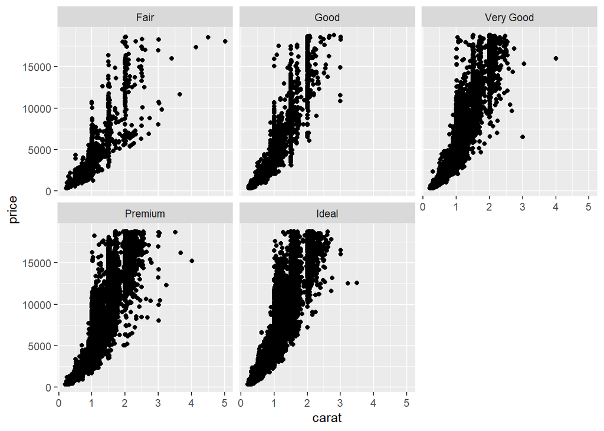

```r
ggplot(data = diamonds) +
geom_point(mapping = aes(x = carat, y = price)) +
facet_wrap(~cut)
```

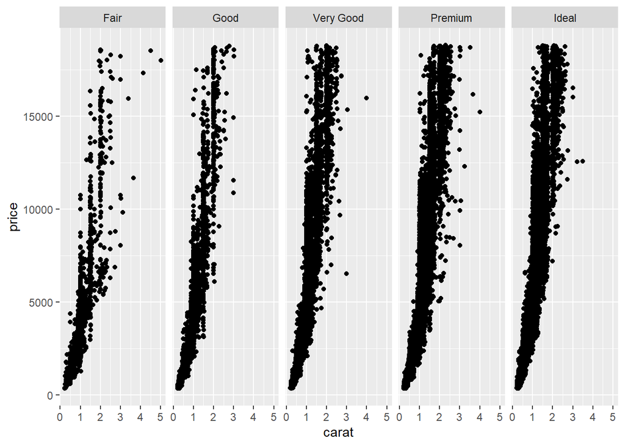

```r
ggplot(data = diamonds) +
geom_point(mapping = aes(x = carat, y = price)) +
facet_grid(. ~ cut)
```

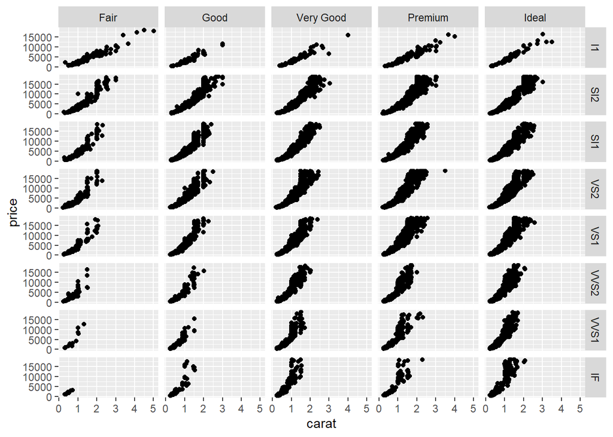

```r
ggplot(data = diamonds) +
geom_point(mapping = aes(x = carat, y = price)) +
facet_grid(clarity ~ cut)
```

These faceting techniques help us visually explore how different categories (like cut and clarity) influence the relationship between the size and price of diamonds.

## Relating the Carat and the Point

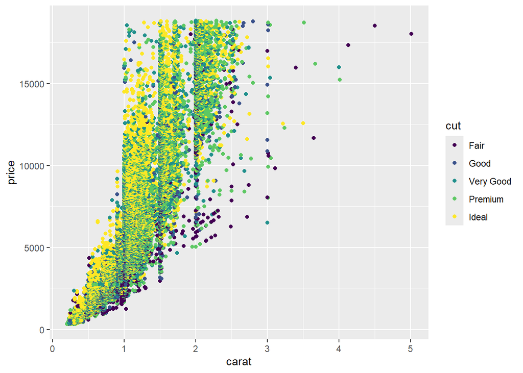

```r
ggplot(data = diamonds) +
geom_point(mapping = aes(x = carat, y = price, color = cut))
```

This relationship explains the apparent paradoxical trend seen in a plot of price vs. carat by highlighting the important role that cut plays in determining diamond prices.

# Lecture 3

## filter()

```r
# subset to diamonds with price at least $10,000
filter(diamonds, price >= 10000)
```

```
## # A tibble: 5,223 × 10
##    carat cut       color clarity depth table price     x     y     z
##    <dbl> <ord>     <ord> <ord>   <dbl> <dbl> <int> <dbl> <dbl> <dbl>
##  1  1.51 Good      H     VS2      64      59 10000  7.25  7.19  4.62
##  2  1.7  Ideal     J     VS2      60.5    58 10002  7.73  7.74  4.68
##  3  1.03 Ideal     E     VVS2     60.6    59 10003  6.5   6.53  3.95
##  4  1.23 Very Good G     VVS2     60.6    55 10004  6.93  7.02  4.23
##  5  1.25 Ideal     F     VS2      61.6    55 10006  6.93  6.96  4.28
##  6  2.01 Very Good I     SI2      61.4    63 10009  8.19  7.96  4.96
##  7  1.21 Very Good F     VS1      62.3    58 10009  6.76  6.85  4.24
##  8  1.51 Premium   I     VS2      59.9    60 10010  7.42  7.36  4.43
##  9  1.01 Fair      D     SI2      64.6    58 10011  6.25  6.2   4.02
## 10  1.05 Ideal     F     VVS2     60.5    55 10011  6.67  6.58  4.01
## # ℹ 5,213 more rows
```

```r
# subset to diamonds with price at least $10,000 AND clarity VVS1 or IF
filter(diamonds, price >= 10000 & clarity %in% c("VVS1", "IF"))
```

```
## # A tibble: 415 × 10
##    carat cut       color clarity depth table price     x     y     z
##    <dbl> <ord>     <ord> <ord>   <dbl> <dbl> <int> <dbl> <dbl> <dbl>
##  1  1.01 Very Good F     VVS1     62.9    57 10019  6.35  6.41  4.01
##  2  1.02 Very Good E     IF       61.7    60 10029  6.38  6.52  3.98
##  3  1.03 Very Good F     IF       62.8    57 10032  6.4   6.47  4.04
##  4  1    Very Good F     IF       63.2    63 10046  6.26  6.24  3.95
##  5  1.11 Ideal     G     IF       61.2    54 10053  6.71  6.73  4.11
##  6  1    Ideal     F     VVS1     62.3    53 10058  6.37  6.43  3.99
##  7  1.09 Premium   G     IF       61.3    58 10065  6.64  6.6   4.06
##  8  1.11 Very Good F     VVS1     62.5    59 10069  6.59  6.63  4.13
##  9  1.16 Ideal     G     IF       62.3    55 10082  6.79  6.73  4.21
## 10  1.16 Ideal     G     IF       62      57 10082  6.73  6.7   4.16
## # ℹ 405 more rows
```

A filter operation helps us to observe the data based on certain logical condition. And boolean operators tells us to where the categorical values belongs.

## select()

```r
select(diamonds, carat, cut, color, clarity)
```

```
## # A tibble: 53,940 × 4
##    carat cut       color clarity
##    <dbl> <ord>     <ord> <ord>
##  1  0.23 Ideal     E     SI2
##  2  0.21 Premium   E     SI1
##  3  0.23 Good      E     VS1
##  4  0.29 Premium   I     VS2
##  5  0.31 Good      J     SI2
##  6  0.24 Very Good J     VVS2
##  7  0.24 Very Good I     VVS1
##  8  0.26 Very Good H     SI1
##  9  0.22 Fair      E     VS2
## 10  0.23 Very Good H     VS1
## # ℹ 53,930 more rows
```

## arrange()

```r
arrange(diamonds, carat)
```

```
## # A tibble: 53,940 × 10
##    carat cut       color clarity depth table price     x     y     z
##    <dbl> <ord>     <ord> <ord>   <dbl> <dbl> <int> <dbl> <dbl> <dbl>
##  1   0.2 Premium   E     SI2      60.2    62   345  3.79  3.75  2.27
##  2   0.2 Premium   E     VS2      59.8    62   367  3.79  3.77  2.26
##  3   0.2 Premium   E     VS2      59      60   367  3.81  3.78  2.24
##  4   0.2 Premium   E     VS2      61.1    59   367  3.81  3.78  2.32
##  5   0.2 Premium   E     VS2      59.7    62   367  3.84  3.8   2.28
##  6   0.2 Ideal     E     VS2      59.7    55   367  3.86  3.84  2.3
##  7   0.2 Premium   F     VS2      62.6    59   367  3.73  3.71  2.33
##  8   0.2 Ideal     D     VS2      61.5    57   367  3.81  3.77  2.33
##  9   0.2 Very Good E     VS2      63.4    59   367  3.74  3.71  2.36
## 10   0.2 Ideal     E     VS2      62.2    57   367  3.76  3.73  2.33
## # ℹ 53,930 more rows
```

```r
arrange(diamonds, desc(carat))
```

```
## # A tibble: 53,940 × 10
##    carat cut       color clarity depth table price     x     y     z
##    <dbl> <ord>     <ord> <ord>   <dbl> <dbl> <int> <dbl> <dbl> <dbl>
##  1  5.01 Fair      J     I1       65.5    59 18018 10.7  10.5   6.98
##  2  4.5  Fair      J     I1       65.8    58 18531 10.2  10.2   6.72
##  3  4.13 Fair      H     I1       64.8    61 17329 10     9.85  6.43
##  4  4.01 Premium   I     I1       61      61 15223 10.1  10.1   6.17
##  5  4.01 Premium   J     I1       62.5    62 15223 10.0   9.94  6.24
##  6  4    Very Good I     I1       63.3    58 15984 10.0   9.94  6.31
##  7  3.67 Premium   I     I1       62.4    56 16193  9.86  9.81  6.13
##  8  3.65 Fair      H     I1       67.1    53 11668  9.53  9.48  6.38
##  9  3.51 Premium   J     VS2      62.5    59 18701  9.66  9.63  6.03
## 10  3.5  Ideal     H     I1       62.8    57 12587  9.65  9.59  6.03
## # ℹ 53,930 more rows
```

The arrange operation function helps us to sorts the rows of data. In the result we can see that we arrange the diamonds by carat in ascending and descanding manner.

## Mutate

```r
mutate(diamonds, price_per_carat = price/carat)
```

```
## # A tibble: 53,940 × 11
##    carat cut   color clarity depth table price     x     y     z price_per_carat
##    <dbl> <ord> <ord> <ord>   <dbl> <dbl> <int> <dbl> <dbl> <dbl>           <dbl>
##  1  0.23 Ideal E     SI2      61.5    55   326  3.95  3.98  2.43           1417.
##  2  0.21 Prem… E     SI1      59.8    61   326  3.89  3.84  2.31           1552.
##  3  0.23 Good  E     VS1      56.9    65   327  4.05  4.07  2.31           1422.
##  4  0.29 Prem… I     VS2      62.4    58   334  4.2   4.23  2.63           1152.
##  5  0.31 Good  J     SI2      63.3    58   335  4.34  4.35  2.75           1081.
##  6  0.24 Very… J     VVS2     62.8    57   336  3.94  3.96  2.48           1400
##  7  0.24 Very… I     VVS1     62.3    57   336  3.95  3.98  2.47           1400
##  8  0.26 Very… H     SI1      61.9    55   337  4.07  4.11  2.53           1296.
##  9  0.22 Fair  E     VS2      65.1    61   337  3.87  3.78  2.49           1532.
## 10  0.23 Very… H     VS1      59.4    61   338  4     4.05  2.39           1470.
## # ℹ 53,930 more rows
```

```r
mutate(diamonds, fancy_diamond = price/carat > 10000)
```

```
## # A tibble: 53,940 × 11
##    carat cut     color clarity depth table price     x     y     z fancy_diamond
##    <dbl> <ord>   <ord> <ord>   <dbl> <dbl> <int> <dbl> <dbl> <dbl> <lgl>
##  1  0.23 Ideal   E     SI2      61.5    55   326  3.95  3.98  2.43 FALSE
##  2  0.21 Premium E     SI1      59.8    61   326  3.89  3.84  2.31 FALSE
##  3  0.23 Good    E     VS1      56.9    65   327  4.05  4.07  2.31 FALSE
##  4  0.29 Premium I     VS2      62.4    58   334  4.2   4.23  2.63 FALSE
##  5  0.31 Good    J     SI2      63.3    58   335  4.34  4.35  2.75 FALSE
##  6  0.24 Very G… J     VVS2     62.8    57   336  3.94  3.96  2.48 FALSE
##  7  0.24 Very G… I     VVS1     62.3    57   336  3.95  3.98  2.47 FALSE
##  8  0.26 Very G… H     SI1      61.9    55   337  4.07  4.11  2.53 FALSE
##  9  0.22 Fair    E     VS2      65.1    61   337  3.87  3.78  2.49 FALSE
## 10  0.23 Very G… H     VS1      59.4    61   338  4     4.05  2.39 FALSE
## # ℹ 53,930 more rows
```

```r
mutate(diamonds,
  good_value =
    if_else(
      condition = carat > 2, # check whether carat > 2
      true = price < 5000, # if so, good value if cheaper than $5k
      false = price < 1000 # if not, good value if cheaper than $1k
    )
)
```

```
## # A tibble: 53,940 × 11
##    carat cut       color clarity depth table price     x     y     z good_value
##    <dbl> <ord>     <ord> <ord>   <dbl> <dbl> <int> <dbl> <dbl> <dbl> <lgl>
##  1  0.23 Ideal     E     SI2      61.5    55   326  3.95  3.98  2.43 TRUE
##  2  0.21 Premium   E     SI1      59.8    61   326  3.89  3.84  2.31 TRUE
##  3  0.23 Good      E     VS1      56.9    65   327  4.05  4.07  2.31 TRUE
##  4  0.29 Premium   I     VS2      62.4    58   334  4.2   4.23  2.63 TRUE
##  5  0.31 Good      J     SI2      63.3    58   335  4.34  4.35  2.75 TRUE
##  6  0.24 Very Good J     VVS2     62.8    57   336  3.94  3.96  2.48 TRUE
##  7  0.24 Very Good I     VVS1     62.3    57   336  3.95  3.98  2.47 TRUE
##  8  0.26 Very Good H     SI1      61.9    55   337  4.07  4.11  2.53 TRUE
##  9  0.22 Fair      E     VS2      65.1    61   337  3.87  3.78  2.49 TRUE
## 10  0.23 Very Good H     VS1      59.4    61   338  4     4.05  2.39 TRUE
## # ℹ 53,930 more rows
```

```r
mutate(diamonds,
value =
  case_when(
    carat > 2 & price < 5000 ~ "good", # if carat > 2 and price < 5000, then good
    carat > 1 & price < 2500 ~ "ok", # if carat > 1 and price < 2500, then ok
    TRUE ~ "bad" # otherwise, bad
  )
)
```

```
## # A tibble: 53,940 × 11
##    carat cut       color clarity depth table price     x     y     z value
##    <dbl> <ord>     <ord> <ord>   <dbl> <dbl> <int> <dbl> <dbl> <dbl> <chr>
##  1  0.23 Ideal     E     SI2      61.5    55   326  3.95  3.98  2.43 bad
##  2  0.21 Premium   E     SI1      59.8    61   326  3.89  3.84  2.31 bad
##  3  0.23 Good      E     VS1      56.9    65   327  4.05  4.07  2.31 bad
##  4  0.29 Premium   I     VS2      62.4    58   334  4.2   4.23  2.63 bad
##  5  0.31 Good      J     SI2      63.3    58   335  4.34  4.35  2.75 bad
##  6  0.24 Very Good J     VVS2     62.8    57   336  3.94  3.96  2.48 bad
##  7  0.24 Very Good I     VVS1     62.3    57   336  3.95  3.98  2.47 bad
##  8  0.26 Very Good H     SI1      61.9    55   337  4.07  4.11  2.53 bad
##  9  0.22 Fair      E     VS2      65.1    61   337  3.87  3.78  2.49 bad
## 10  0.23 Very Good H     VS1      59.4    61   338  4     4.05  2.39 bad
## # ℹ 53,930 more rows
```

The mutate function helps us to add another column in an existing column. In this case, we add column while having condition in the dataset. Like, adding a column that indicates wheter the price of the diamond price per carat is at least 10k dollars and the other one if it has a two condition.

## summarise()

```r
summarise(diamonds, num_fancy_diamonds = sum(price/carat > 10000))
```

```
## # A tibble: 1 × 1
##   num_fancy_diamonds
##                <int>
## 1                617
```

```r
summarise(diamonds,
  num_fancy_diamonds = sum(price/carat > 10000),
  mean_diamond_price = mean(price))
```

```
## # A tibble: 1 × 2
##   num_fancy_diamonds mean_diamond_price
##                <int>              <dbl>
## 1                617              3933.
```

```r
diamonds %>%
  filter(carat >= 1, price < 1000) %>%
  summarise(any_diamonds = n() > 0)
```

```
## # A tibble: 1 × 1
##   any_diamonds
##   <lgl>
## 1 FALSE
```

Summarise is the operation that calculates the summary of the dataset that combines all of the rows in the data. In the last result. We use summarise operation in determining if there is any diamonds at least one that cost less than $1000 dollars

## Multi-step transformations

## The pipe

```r
diamonds %>% # pipe in the data
filter(cut == "Premium") %>% # restrict to premium cut diamonds
mutate(price_per_carat = price/carat) %>% # add price_per_carat variable
arrange(desc(price_per_carat))
```

```
## # A tibble: 13,791 × 11
##    carat cut   color clarity depth table price     x     y     z price_per_carat
##    <dbl> <ord> <ord> <ord>   <dbl> <dbl> <int> <dbl> <dbl> <dbl>           <dbl>
##  1  1.07 Prem… D     IF       60.9    58 18279  6.67  6.57  4.03          17083.
##  2  1.01 Prem… D     IF       61.6    56 16234  6.46  6.43  3.97          16073.
##  3  1.02 Prem… D     IF       61.5    60 15370  6.52  6.45  3.99          15069.
##  4  1.04 Prem… D     IF       60.6    56 15671  6.6   6.54  3.98          15068.
##  5  1.02 Prem… D     IF       61.5    60 15231  6.45  6.52  3.99          14932.
##  6  1.21 Prem… D     VVS1     60.1    59 17192  6.96  6.88  4.16          14208.
##  7  1.31 Prem… D     VVS1     62.8    55 17496  7.01  6.95  4.38          13356.
##  8  1.34 Prem… E     IF       61.8    58 17663  7.15  7.08  4.4           13181.
##  9  1.2  Prem… D     VVS1     62.1    59 15686  0     0     0             13072.
## 10  1.28 Prem… E     IF       59.8    59 15806  7.1   7.07  4.24          12348.
## # ℹ 13,781 more rows
```

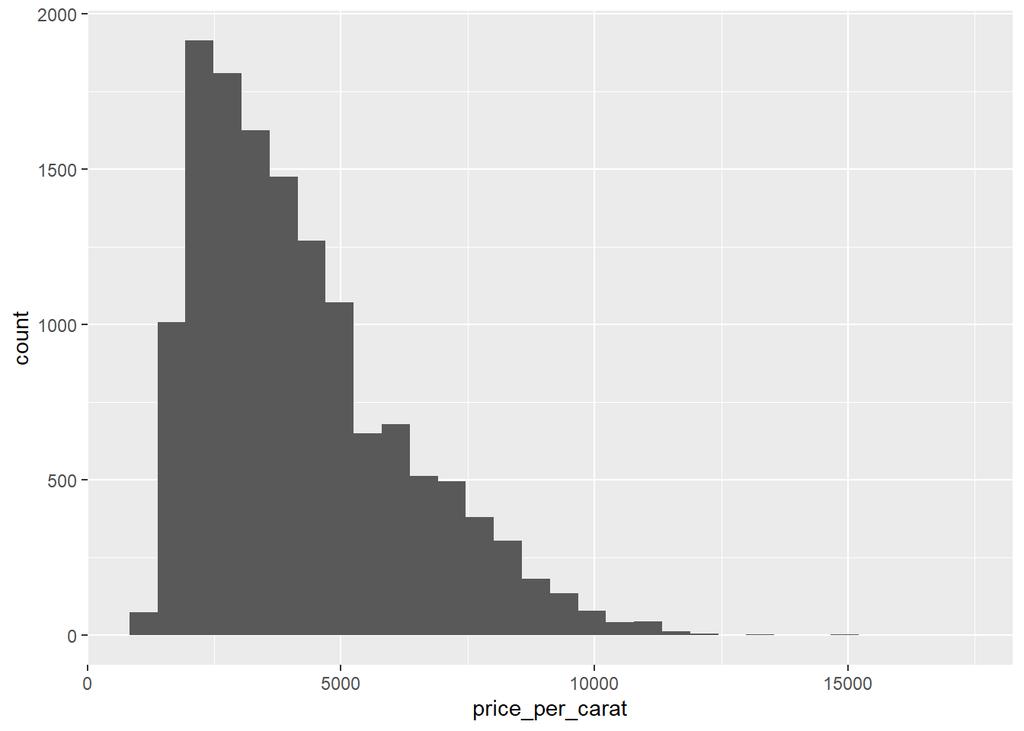

```r
diamonds %>% # pipe in the data
filter(cut == "Premium") %>% # restrict to premium cut diamonds
mutate(price_per_carat = price/carat) %>% # add price_per_carat variable
ggplot() + # start a ggplot
geom_histogram(aes(x = price_per_carat)) # add a histogram
```

```r
diamonds %>%
  filter(carat >= 1) %>%
  summarise(mean_price = mean(price))
```

```
## # A tibble: 1 × 1
##   mean_price
##        <dbl>
## 1      8142.
```

The pipe operation is very useful to us, as it allows us to apply several operations in the data in sequence. The example are the result in the coding. And in the third result, we did compute the mean price of the diamond at least one carat

## Group_by

```r
diamonds %>% # pipe in the data
  group_by(cut) %>% # group by cut
  summarise(max_price = max(price)) # find the max price for each cut
```

```
## # A tibble: 5 × 2
##   cut       max_price
##   <ord>         <int>
## 1 Fair          18574
## 2 Good          18788
## 3 Very Good     18818
## 4 Premium       18823
## 5 Ideal         18806
```

```r
diamonds %>% # pipe in the data
  group_by(cut, clarity) %>% # group by both cut and clarity
  summarise(max_price = max(price)) # find the max price for each group
```

[output not shown]

```
## # A tibble: 40 × 3
## # Groups:   cut [5]
##    cut   clarity max_price
##    <ord> <ord>       <int>
##  1 Fair  I1          18531
##  2 Fair  SI2         18308
##  3 Fair  SI1         18574
##  4 Fair  VS2         18565
##  5 Fair  VS1         17995
##  6 Fair  VVS2        16364
##  7 Fair  VVS1        12648
##  8 Fair  IF           3205
##  9 Good  I1          11548
## 10 Good  SI2         18788
## # ℹ 30 more rows
```

```r
diamonds %>% # pipe in the data
  group_by(cut, clarity) %>% # group by both cut and clarity
  summarise(max_price = max(price)) %>% # find the max price for each group
  ungroup()
```

[output not shown]

```
## # A tibble: 40 × 3
##    cut   clarity max_price
##    <ord> <ord>       <int>
##  1 Fair  I1          18531
##  2 Fair  SI2         18308
##  3 Fair  SI1         18574
##  4 Fair  VS2         18565
##  5 Fair  VS1         17995
##  6 Fair  VVS2        16364
##  7 Fair  VVS1        12648
##  8 Fair  IF           3205
##  9 Good  I1          11548
## 10 Good  SI2         18788
## # ℹ 30 more rows
```

```r
library(dplyr)

diamonds %>%
  group_by(cut) %>%
  summarise(count = n())
```

```
## # A tibble: 5 × 2
##   cut       count
##   <ord>     <int>
## 1 Fair       1610
## 2 Good       4906
## 3 Very Good 12082
## 4 Premium   13791
## 5 Ideal     21551
```

The dplyr to group the diamonds dataset by different categorical variables and compute summary statistics. For instance, the firstgroups the data by cut and calculates the maximum price for each cut category, helping to identify the most expensive diamond for each quality grade. In the second snippet, the data is grouped by both cut and clarity, then the maximum price is calculated for each combination, providing insights into the highest-priced diamonds within each pair of cut and clarity. The final example calculates the count of diamonds in each cut category, showing how many diamonds are available in each cut type. These operations are significant as they allow for quick aggregation and exploration of key trends in the dataset, such as price variations across different cuts and clarities, and the distribution of diamonds within each cut category.

## Storing the transformed data

```r
diamonds
```

```
## # A tibble: 53,940 × 10
##    carat cut       color clarity depth table price     x     y     z
##    <dbl> <ord>     <ord> <ord>   <dbl> <dbl> <int> <dbl> <dbl> <dbl>
##  1  0.23 Ideal     E     SI2      61.5    55   326  3.95  3.98  2.43
##  2  0.21 Premium   E     SI1      59.8    61   326  3.89  3.84  2.31
##  3  0.23 Good      E     VS1      56.9    65   327  4.05  4.07  2.31
##  4  0.29 Premium   I     VS2      62.4    58   334  4.2   4.23  2.63
##  5  0.31 Good      J     SI2      63.3    58   335  4.34  4.35  2.75
##  6  0.24 Very Good J     VVS2     62.8    57   336  3.94  3.96  2.48
##  7  0.24 Very Good I     VVS1     62.3    57   336  3.95  3.98  2.47
##  8  0.26 Very Good H     SI1      61.9    55   337  4.07  4.11  2.53
##  9  0.22 Fair      E     VS2      65.1    61   337  3.87  3.78  2.49
## 10  0.23 Very Good H     VS1      59.4    61   338  4     4.05  2.39
## # ℹ 53,930 more rows
```

```r
max_prices <- diamonds %>% # pipe in the data
  group_by(cut) %>% # group by cut
  summarise(max_price = max(price)) # find the max price for each cut
max_prices
```

```
## # A tibble: 5 × 2
##   cut       max_price
##   <ord>         <int>
## 1 Fair          18574
## 2 Good          18788
## 3 Very Good     18818
## 4 Premium       18823
## 5 Ideal         18806
```

The code demonstrates that applying functions like group_by() and summarise() does not modify the original diamonds dataset. To save the result of a transformation, you need to explicitly assign it to a new variable using the <- operator. In the example, the maximum price for each cut category is calculated and stored in a new variable called max_prices, while the original diamonds dataset remains unchanged. This highlights the need to save transformed data if you want to retain the changes for further use.

## Exercises

```r
library(dplyr)

min_price_method1 <- diamonds %>%
  summarise(min_price = min(price))

min_price_method2 <- diamonds %>%
  arrange(price) %>%
  slice(1) %>%
  select(price)

diamonds_1_5_times_width <- diamonds %>%
  filter(x >= 1.5 * y) %>%
  summarise(count = n())

median_carat_by_cut <- diamonds %>%
  filter(color %in% c("D", "E", "F", "G")) %>%
  group_by(cut) %>%
  summarise(median_carat = median(carat))

list(
  min_price_method1 = min_price_method1,
  min_price_method2 = min_price_method2,
  diamonds_1_5_times_width = diamonds_1_5_times_width,
  median_carat_by_cut = median_carat_by_cut
)
```

```
## $min_price_method1
## # A tibble: 1 × 1
##   min_price
##       <int>
## 1       326
##
## $min_price_method2
## # A tibble: 1 × 1
##   price
##   <int>
## 1   326
##
## $diamonds_1_5_times_width
## # A tibble: 1 × 1
##   count
##   <int>
## 1    10
##
## $median_carat_by_cut
## # A tibble: 5 × 2
##   cut       median_carat
##   <ord>            <dbl>
## 1 Fair              0.91
## 2 Good              0.72
## 3 Very Good         0.7
## 4 Premium           0.71
## 5 Ideal             0.52
```

The exercise shows the minimum diamond price in the dataset, shows on the length of diamonds that reach at least one a half times their width. And lastly, it also states on what is the median of the carats for diamonds in each cut

##Lecture 4

##Data Import

```r
heights = read.csv("C:/Users/sbcvj/Downloads/heights.csv")

head(heights)
```

```
##    earn   height    sex ed age  race
## 1 50000 74.42444   male 16  45 white
## 2 60000 65.53754 female 16  58 white
## 3 30000 63.62920 female 16  29 white
## 4 50000 63.10856 female 16  91 other
## 5 51000 63.40248 female 17  39 white
## 6  9000 64.39951 female 15  26 white
```

##Tidy Data

##Generating Tables from the lecture

## Table1

```r
table1
```

```
## # A tibble: 6 × 4
##   country      year  cases population
##   <chr>       <dbl>  <dbl>      <dbl>
## 1 Afghanistan  1999    745   19987071
## 2 Afghanistan  2000   2666   20595360
## 3 Brazil       1999  37737  172006362
## 4 Brazil       2000  80488  174504898
## 5 China        1999 212258 1272915272
## 6 China        2000 213766 1280428583
```

Table 1 represents a single observation, that defined by the country and year. So the country and year represents the country and year in the data. The cases records the cases within that country and year, and the population provides the total population within that years and countries.

## Table 2

```r
table2
```

```
## # A tibble: 12 × 4
##    country      year type            count
##    <chr>       <dbl> <chr>           <dbl>
##  1 Afghanistan  1999 cases             745
##  2 Afghanistan  1999 population   19987071
##  3 Afghanistan  2000 cases            2666
##  4 Afghanistan  2000 population   20595360
##  5 Brazil       1999 cases           37737
##  6 Brazil       1999 population  172006362
##  7 Brazil       2000 cases           80488
##  8 Brazil       2000 population  174504898
##  9 China        1999 cases          212258
## 10 China        1999 population 1272915272
## 11 China        2000 cases          213766
## 12 China        2000 population 1280428583
```

the country column contains the name of the country for which the data is recorded. The year column represents the year of the data. The data includes information for each country across multiple years. The type column specifies the type of data recorded.

## Table 3

```r
table3
```

```
## # A tibble: 6 × 3
##   country      year rate
##   <chr>       <dbl> <chr>
## 1 Afghanistan  1999 745/19987071
## 2 Afghanistan  2000 2666/20595360
## 3 Brazil       1999 37737/172006362
## 4 Brazil       2000 80488/174504898
## 5 China        1999 212258/1272915272
## 6 China        2000 213766/1280428583
```

Table 3 continues to show a country and a year, but rather than having individual columns for cases and population, these two variables are merged into one column named rate.

The rate column contains values expressed as a fraction, with the numerator indicating cases and the denominator indicating population.

Nevertheless, this table is disorganized, as one column holds two variables, complicating the separation and effective analysis of the data.

## Table 4a

```r
table4a
```

```
## # A tibble: 3 × 3
##   country     `1999` `2000`
##   <chr>        <dbl>  <dbl>
## 1 Afghanistan    745   2666
## 2 Brazil       37737  80488
## 3 China       212258 213766
```

In table4, every row reporesents for a country, yet the year variable isn’t directly included as a column.

The years are visualized as distinct column headings. The figures in these columns indicate the cases documented in each corresponding year.

This arrangement is regarded as wide format, in which observations are distributed across various columns instead of being structured as separate variables in individual rows. Although this format is helpful for presentation, it lacks neatness as the year variable is used as column headers rather than being in a separate column.

## Table 4b

```r
table4b
```

```
## # A tibble: 3 × 3
##   country         `1999`     `2000`
##   <chr>            <dbl>      <dbl>
## 1 Afghanistan   19987071   20595360
## 2 Brazil       172006362  174504898
## 3 China       1272915272 1280428583
```

Table 4b illustrates a nation, showcasing population data collected over many years. Every year constitutes an individual column, and population serves as the corresponding values.

This format is not tidy since the year variable should preferably be housed in a single column instead of being distributed among various column names.

## Longer

Pivoting Table 4a and Table 4b to a new pair of values:

```r
table4a %>%
pivot_longer(cols = c(`1999`, `2000`), names_to = "year", values_to = "cases")
```

```
## # A tibble: 6 × 3
##   country     year   cases
##   <chr>       <chr>  <dbl>
## 1 Afghanistan 1999     745
## 2 Afghanistan 2000    2666
## 3 Brazil      1999   37737
## 4 Brazil      2000   80488
## 5 China       1999  212258
## 6 China       2000  213766
```

```r
table4b %>%
pivot_longer(cols = c(`1999`, `2000`), names_to = "year", values_to = "population")
```

```
## # A tibble: 6 × 3
##   country     year  population
##   <chr>       <chr>      <dbl>
## 1 Afghanistan 1999    19987071
## 2 Afghanistan 2000    20595360
## 3 Brazil      1999   172006362
## 4 Brazil      2000   174504898
## 5 China       1999  1272915272
## 6 China       2000  1280428583
```

the difference between Table4a and Table4b is that in table4a, the figures in the chosen columns indicate the number of instances.While table4b, the figures indicate the population for every year.Thus, the code to implement this is very similar, but we modify values to as each table signifies different variables. This conversion guarantees that every variable occupies a unique column, simplifying the process of analyzing and visualizing trends throughout time.Distinction between the code for Table4a and Table4b. In table4a, the figures in the chosen columns indicate the total number of cases.In table4b, the figures indicate the population for every year.

## Wider

```r
table2 %>%
  pivot_wider(names_from = type, values_from = count)
```

```
## # A tibble: 6 × 4
##   country      year  cases population
##   <chr>       <dbl>  <dbl>      <dbl>
## 1 Afghanistan  1999    745   19987071
## 2 Afghanistan  2000   2666   20595360
## 3 Brazil       1999  37737  172006362
## 4 Brazil       2000  80488  174504898
## 5 China        1999 212258 1272915272
## 6 China        2000 213766 1280428583
```

Tidying the simple tibble from the lecture:

```r
tribble(
  ~pregnant, ~male, ~female,
  "yes", NA, 10,
  "no", 20, 12
) %>%
  pivot_longer(cols = c(male, female), names_to = "gender", values_to = "count")
```

```
## # A tibble: 4 × 3
##   pregnant gender count
##   <chr>    <chr>  <dbl>
## 1 yes      male      NA
## 2 yes      female    10
## 3 no       male      20
## 4 no       female    12
```

pivot_wider function is used to maximize the data from long format to wide format, where unique values from a column (type in this case) become column names, and corresponding values (count) fill these new columns. pivot_longer function is used to gather data from wide format to long format, where columns (male, female) are merged into a single column (gender), and their corresponding values are placed into a new column (count).

## Joining

Calling the tidy versions of table4a and table4b:

```r
tidy4a <- table4a %>%
pivot_longer(c(`1999`, `2000`), names_to = "year", values_to = "cases")
tidy4b <- table4b %>%
pivot_longer(c(`1999`, `2000`), names_to = "year", values_to = "population")

tidy4a
```

```
## # A tibble: 6 × 3
##   country     year   cases
##   <chr>       <chr>  <dbl>
## 1 Afghanistan 1999     745
## 2 Afghanistan 2000    2666
## 3 Brazil      1999   37737
## 4 Brazil      2000   80488
## 5 China       1999  212258
## 6 China       2000  213766
```

```r
tidy4b
```

```
## # A tibble: 6 × 3
##   country     year  population
##   <chr>       <chr>      <dbl>
## 1 Afghanistan 1999    19987071
## 2 Afghanistan 2000    20595360
## 3 Brazil      1999   172006362
## 4 Brazil      2000   174504898
## 5 China       1999  1272915272
## 6 China       2000  1280428583
```

Since both tables have the same country in the dataset, we can form a join in these tables using left_join() function

```r
left_join(x = tidy4a, y = tidy4b, by = c("country", "year"))
```

```
## # A tibble: 6 × 4
##   country     year   cases population
##   <chr>       <chr>  <dbl>      <dbl>
## 1 Afghanistan 1999     745   19987071
## 2 Afghanistan 2000    2666   20595360
## 3 Brazil      1999   37737  172006362
## 4 Brazil      2000   80488  174504898
## 5 China       1999  212258 1272915272
## 6 China       2000  213766 1280428583
```

## Exercise

```r
x <- tribble(
  ~state, ~population,
  "PA", 12.8,
  "TX", 28.6,
  "NY", 19.5
  )
y <- tribble(
  ~state, ~capital,
  "TX", "Austin",
  "CA", "Sacramento",
  "NY", "New York City",
  "MI", "Lansing"
  )
```

We can combine these tibbles using a join operation to create a more complete dataset with both population and capital city information for each state.Allowing us to analyze relationships between population size and capital cities, or any other metrics.

##Separating

From table3, the rate column contains both cases and population variables, and it needs to be splitted into two variables.Using the separate() function, we get:

```r
table3 %>%
  separate(rate, into = c("cases", "population"))
```

```
## # A tibble: 6 × 4
##   country      year cases  population
##   <chr>       <dbl> <chr>  <chr>
## 1 Afghanistan  1999 745    19987071
## 2 Afghanistan  2000 2666   20595360
## 3 Brazil       1999 37737  172006362
## 4 Brazil       2000 80488  174504898
## 5 China        1999 212258 1272915272
## 6 China        2000 213766 1280428583
```

Rewriting the code to get a similar result:

```r
table3 %>%
  separate(rate, into = c("cases", "population"), sep = "/")
```

```
## # A tibble: 6 × 4
##   country      year cases  population
##   <chr>       <dbl> <chr>  <chr>
## 1 Afghanistan  1999 745    19987071
## 2 Afghanistan  2000 2666   20595360
## 3 Brazil       1999 37737  172006362
## 4 Brazil       2000 80488  174504898
## 5 China        1999 212258 1272915272
## 6 China        2000 213766 1280428583
```

From the table, we can see that cases and population are character columns. We might need to convert to better types using convert() = TRUE:

```r
tibble3 <- table3 %>%
  separate(rate, into = c("cases", "population"), convert =
             TRUE)

tibble3
```

```
## # A tibble: 6 × 4
##   country      year  cases population
##   <chr>       <dbl>  <int>      <int>
## 1 Afghanistan  1999    745   19987071
## 2 Afghanistan  2000   2666   20595360
## 3 Brazil       1999  37737  172006362
## 4 Brazil       2000  80488  174504898
## 5 China        1999 212258 1272915272
## 6 China        2000 213766 1280428583
```

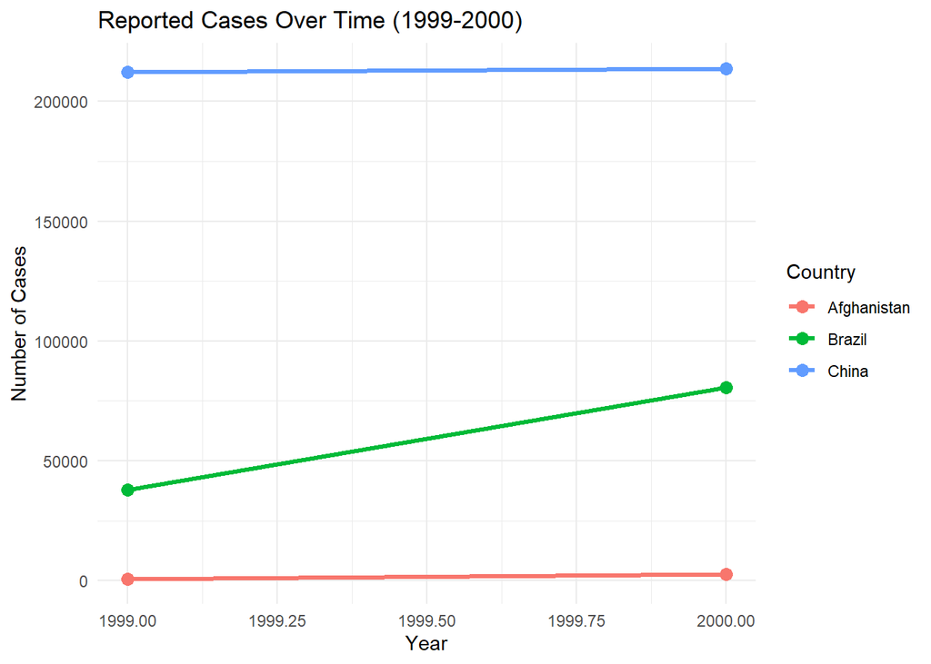

```r
data <- tibble3

ggplot(data, aes(x = year, y = cases, group = country, color = country)) +
  geom_line(size = 1.2) +
  geom_point(size = 3) +
  labs(title = "Reported Cases Over Time (1999-2000)",
       x = "Year",
       y = "Number of Cases",
       color = "Country") +
  theme_minimal()
```

This data set includes analyzed reported cases and population statistics for Afghanistan, Brazil, and China from 1999 and 2000. Population increase was noted in all three nations. China possessed the highest population, succeeded by Brazil and Afghanistan.

In terms of cases per population, Afghanistan showed the highest relative growth (0.0037% to 0.0129%), indicating a significant increase in documented infections. Brazil demonstrated a notable rise (0.022% to 0.046%). Conversely, China’s incidence rate stayed almost the same (~0.0167%). These trends illustrate differences in case increase in relation to population size in various areas.

## Missing values

```r
stocks <- tibble(
  year = c(2015, 2015, 2015, 2015, 2016, 2016, 2016),
  qtr = c( 1, 2, 3, 4, 2, 3, 4),
  return = c(1.88, 0.59, 0.35, NA, 0.92, 0.17, 2.66)
)

stocks
```

```
## # A tibble: 7 × 3
##    year   qtr return
##   <dbl> <dbl>  <dbl>
## 1  2015     1   1.88
## 2  2015     2   0.59
## 3  2015     3   0.35
## 4  2015     4  NA
## 5  2016     2   0.92
## 6  2016     3   0.17
## 7  2016     4   2.66
```

From the table, we can see that there is a missing value in the fourth row. We might need to clean the data.

Pivoting the data set wider:

```r
stocks %>%
  pivot_wider(names_from = year, values_from = return)
```

```
## # A tibble: 4 × 3
##     qtr `2015` `2016`
##   <dbl>  <dbl>  <dbl>
## 1     1   1.88  NA
## 2     2   0.59   0.92
## 3     3   0.35   0.17
## 4     4  NA      2.66
```

omitting the missing values:

```r
tribble4 <- stocks %>%
  na.omit()

tribble4
```

```
## # A tibble: 6 × 3
##    year   qtr return
##   <dbl> <dbl>  <dbl>
## 1  2015     1   1.88
## 2  2015     2   0.59
## 3  2015     3   0.35
## 4  2016     2   0.92
## 5  2016     3   0.17
## 6  2016     4   2.66
```